# TGF-b attenuates tumor response to PD-L1 blockade by contributing to exclusion of T cells - Figure 2 and related data

Dorothee Nickles

2021-01-28 01:38:27

```r
## libraries
library(DESeq2)
library(limma)
library(edgeR)
library(corrplot)
#library(RColorBrewer)
```

```r
# gene sets
data(human_gene_signatures)
ind_genes <- human_gene_signatures

# colors
data(color_palettes)

# variables
goi <- names(ind_genes)
ml <- "FMOne mutation burden per MB"

# font sizes
labCex <- 0.9
namesCex <- 0.9
legendCex <- 0.9
titleCex <- 1
axisCex <- 0.9
titleF <- 1
```

```r
# load
data(fmone)
data(cds)
cds2 <- cds

# normalize
geneNames <- setNames(fData(cds2)$Symbol,
  as.character(rownames(fData(cds2))))
voomD <- filterNvoom(counts(cds2),
  minSamples=ncol(counts(cds2))/10,
  minCpm=0.25)
m <- voomD$E
m <- t(scale( t( m ),
  center=TRUE,
  scale=TRUE)
)
# add signature scores to pData()
m2 <- m
rownames(m2) <- geneNames[rownames(m2)]

# calculate gene set scores
for (sig in goi) {
  pData(cds2)[, sig] <- NA
  genes <- ind_genes[[sig]]
  genes <- genes[genes %in% rownames(m2)]
  tmp <- m2[genes, , drop=FALSE]
  pData(cds2)[, sig] <- gsScore(tmp)
}
```

# Figure 2b

```r
tmpDat <- pData(cds2)[! is.na(pData(cds2)$"Immune phenotype"),]
citPie <- prop.table(table(tmpDat$"Immune phenotype"))
print(citPie)
```

```
##
##    desert  excluded  inflamed
## 0.2676056 0.4718310 0.2605634
```

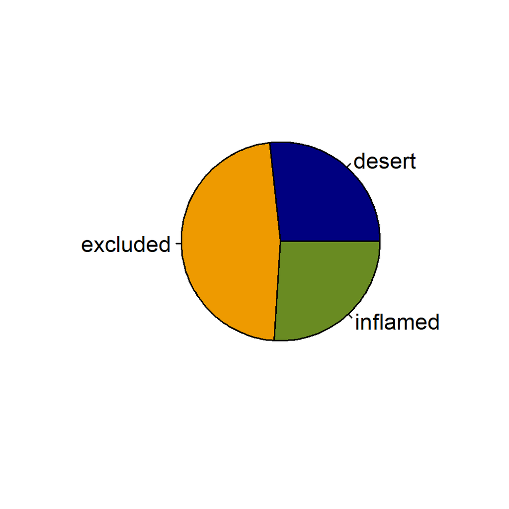

```r
pie(citPie,
  col=color_palettes[["cit_palette"]])
```

# Figure 2c, d and e

```
## [1] "Likelihood ratio test P for CD 8 T effector by immune phenotype: 2.29e-29"
## [1] "Wilcoxon p-values (unadjusted)"
##   desert excluded inflamed
##     0.77     0.52     0.05
## [1] "T test p-values (unadjusted)"
##   desert excluded inflamed
##    0.670    0.350    0.014
## [1] "Adjusted t test p-values"
##   desert excluded inflamed
##    1.000    1.000    0.042
```

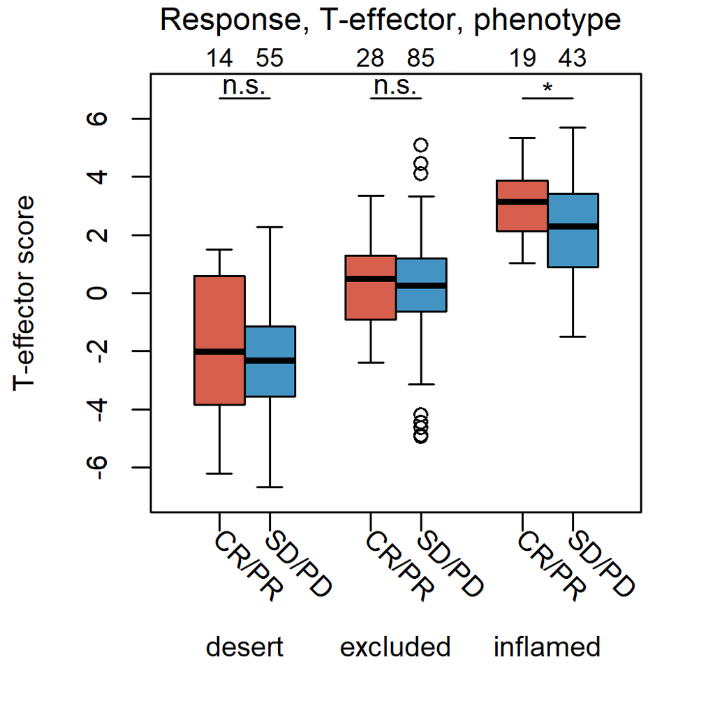

```
## [1] "Likelihood ratio test P for gene19 by immune phenotype: 0.0327"
## [1] "Wilcoxon p-values (unadjusted)"
##   desert excluded inflamed
##   0.7600   0.0057   0.9900
## [1] "T test p-values (unadjusted)"
##   desert excluded inflamed
##   0.7000   0.0022   0.7600
## [1] "Adjusted t test p-values"
##   desert excluded inflamed
##   1.0000   0.0066   1.0000
```

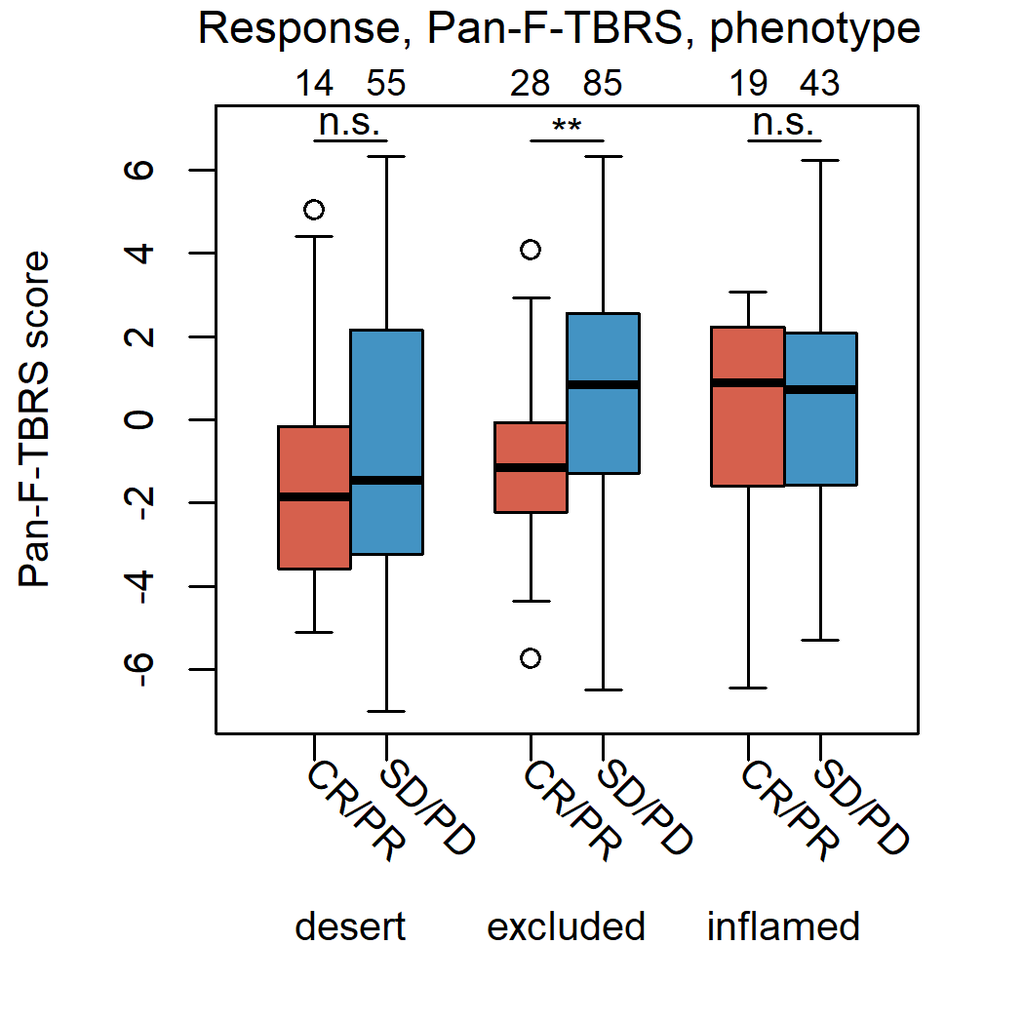

```r
sigs <- c("CD 8 T effector", "gene19")
resp <- "binaryResponse"
feat <- "Immune phenotype"

# subset data
dat <- pData(cds2)[!is.na(pData(cds2)[, resp]) & !is.na(pData(cds2)[, feat]), ]
nSamples <- table(dat[, resp], dat$"Immune phenotype")


for (sig in sigs) {

  # calculate statistics
  anovaP <- getPfromAnova(dat[, sig], dat[, feat])
  print(paste("Likelihood ratio test P for", sig, "by immune phenotype:", anovaP))

  pvals2 <- c()
  for (cit in levels(pData(cds2)[, feat])) {
    tmp <- dat[dat$"Immune phenotype" == cit,]
    pvals2 <- c(pvals2,
      signif(wilcox.test(tmp[, sig] ~ tmp[, resp])$p.value, 2))
  }
  print("Wilcoxon p-values (unadjusted)")
  print(setNames(pvals2, levels(pData(cds2)[, feat])))

  pvals2 <- c()
  for (cit in levels(pData(cds2)[, feat])) {
    tmp <- dat[dat$"Immune phenotype" == cit,]
    pvals2 <- c(pvals2,
      signif(t.test(tmp[, sig] ~ tmp[, resp])$p.value, 2))
  }

  print("T test p-values (unadjusted)")
  print(setNames(pvals2, levels(pData(cds2)[, feat])))

  pvals2 <- ifelse(pvals2 * 3 > 1, 1, pvals2 * 3)
  print("Adjusted t test p-values")
  print(setNames(pvals2,
    levels(pData(cds2)[, feat])))
  pvals3 <- pLevel(pvals2)

  # plot data
  par(mar=c(5.5, 4.1, 2, 2))

  tmp <- lapply(levels(pData(cds2)[, feat]), function(cit) {
    if (cit == "inflamed") {
      list("CR/PR"=dat[, sig][dat[, resp] == "CR/PR" & dat$"Immune phenotype" == cit],
        "SD/PD"=dat[, sig][dat[, resp] == "SD/PD" & dat$"Immune phenotype" == cit])
    } else {
      list("CR/PR"=dat[, sig][dat[, resp] == "CR/PR" & dat$"Immune phenotype" == cit],
        "SD/PD"=dat[, sig][dat[, resp] == "SD/PD" & dat$"Immune phenotype" == cit],
        y=numeric(0))
    }
  })

    if (sig == "gene19") {
      sig <- "Pan-F-TBRS"
    }
    if (sig == "CD 8 T effector") {
      sig <- "T-effector"
    }

  at.x <- seq(1, by=0.5, length.out=8)
  a <- boxplot(unlist(tmp, recursive=FALSE),
    ylab=paste(sig, "score"),
    col=color_palettes$response_palette[c(1,2,1,1,2,1,1,2)],
    cex.axis=axisCex,
    cex.lab=labCex,
    cex.names=namesCex,
    whisklty = 1,
    ylim=c(-7,7),
    xaxt="n",
    at=at.x,
    boxwex=0.5)
  axis(1,
    at=c(1,1.5,2.5,3,4,4.5),
    labels=rep("", 6))
  mtext(levels(pData(cds2)$"Immune phenotype"),
    side=1,
    at=c(1.25, 2.75, 4.25),
    line=3.1,
    cex=namesCex)
  text(x = c(1,1.5,2.5,3,4,4.5),
    y = par("usr")[3] - 0.7 ,
    labels = rep(c("CR/PR", "SD/PD"), 3),
    srt = -45,
    xpd = TRUE,
    adj=0,
    cex=namesCex)
  mtext(nSamples,
    side=3,
    at=c(1,1.5,2.5,3,4,4.5),
    line=0,
    cex=0.8)
  mtext(paste0("Response, ", sig, ", phenotype"),
    side=3,
    at=2.7,
    line=1,
    font=titleF,
    cex=titleCex)

  yrange <- par("usr")[4] - par("usr")[3]
  yunit <- yrange/35
  segments(x0=1,
    x1=1.5,
    y0=par("usr")[4] - yunit * 2,
    y1=par("usr")[4] - yunit * 2,
    col="black",
    xpd=TRUE,
    lwd=1)
  segments(x0=2.5,
    x1=3,
    y0=par("usr")[4] - yunit * 2,
    y1=par("usr")[4] - yunit * 2,
    col="black",
    xpd=TRUE,
    lwd=1)
  segments(x0=4,
    x1=4.5,
    y0=par("usr")[4] - yunit * 2,
    y1=par("usr")[4] - yunit * 2,
    col="black",
    xpd=TRUE,
    lwd=1)
  text(y=par("usr")[4] - yunit,
    x=c(1.25, 2.75, 4.25),
    labels=pvals3,
    cex=axisCex)

}
```

```r
tmpDat <- pData(cds2)[!is.na(pData(cds2)[, ml]), ]
tmpDat <- tmpDat[tmpDat[, ml] > 0, ]

tmpDat <- tmpDat[! is.na(tmpDat[, feat]),]

sig <- ml

  feat <- "Immune phenotype"
  resp <- "binaryResponse"

  dat <- data.frame("Signature"= log2(tmpDat[, sig]),
    "Immunophenotype"= tmpDat[, feat],
    "Response"= tmpDat[, resp],
    check.names=FALSE)
  dat <- dat[!is.na(dat$Response) & !is.na(dat$Immunophenotype), ]
  nSamples <- table(dat$Response, dat$Immunophenotype)

  pvals2 <- c()
  for (cit in levels(pData(cds2)[, feat])) {
    tmp <- dat[dat$Immunophenotype == cit,]
    pvals2 <- c(pvals2,
      signif(wilcox.test(tmp$Signature ~ tmp$Response)$p.value, 2))
  }
  print("Wilcoxon p-values (unadjusted)")
```

```
## [1] "Wilcoxon p-values (unadjusted)"
```

```r
  print(setNames(pvals2, levels(pData(cds2)[, feat])))
```

```
##   desert excluded inflamed
##  2.8e-01  3.1e-05  2.5e-03
```

```r
  pvals2 <- c()
  for (cit in levels(pData(cds2)[, feat])) {
    tmp <- dat[dat$Immunophenotype == cit,]
    pvals2 <- c(pvals2,
      signif(t.test(tmp$Signature ~ tmp$Response)$p.value, 2))
  }

  print("T test p-values (unadjusted)")
```

```
## [1] "T test p-values (unadjusted)"
```

```r
  print(setNames(pvals2, levels(pData(cds2)[, feat])))
```

```
##   desert excluded inflamed
##  0.35000  0.00003  0.00086
```

```r
  pvals2 <- ifelse(pvals2 * 3 > 1, 1, pvals2 * 3)
  print("Adjusted t test p-values")
```

```
## [1] "Adjusted t test p-values"
```

```r
  print(setNames(pvals2,
    levels(pData(cds2)[, feat])))
```

```
##   desert excluded inflamed
##  1.00000  0.00009  0.00258
```

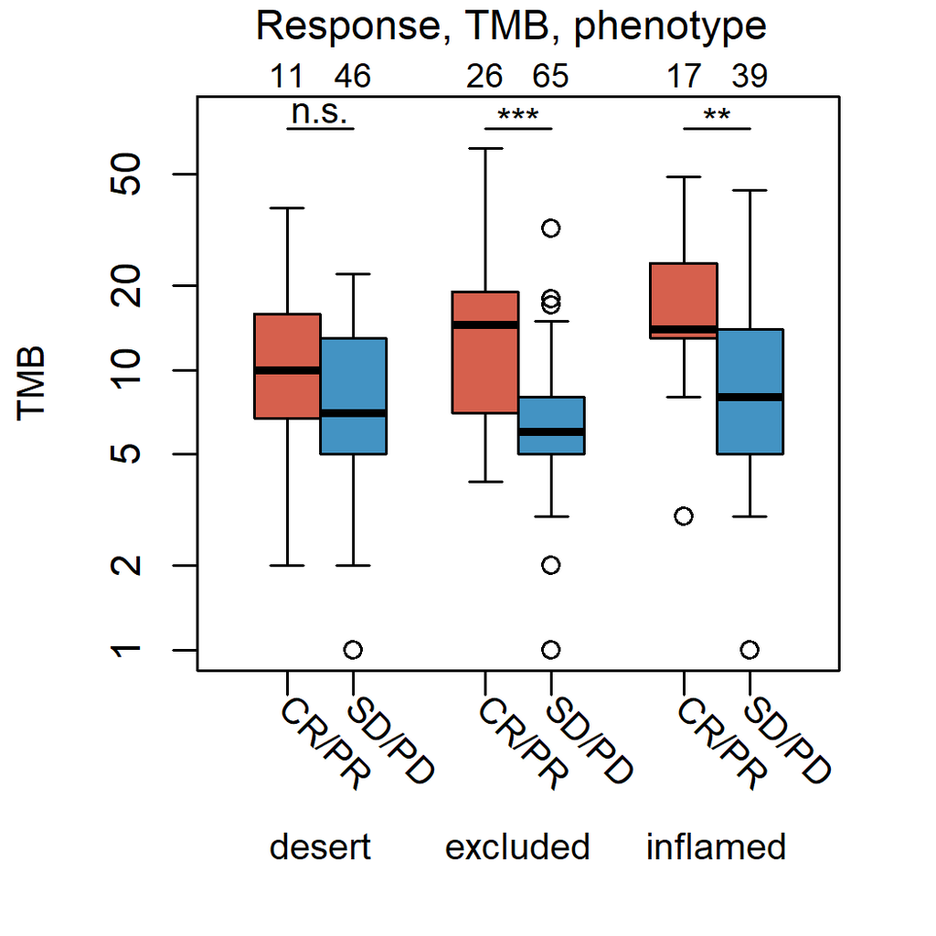

```r
  pvals3 <- ifelse(pvals2 < 0.001, "***",
    ifelse(pvals2 < 0.01, "**",
      ifelse(pvals2 < 0.05, "*",
        ifelse(pvals2 < 0.1, ".", "n.s."))))

  tmp <- lapply(levels(pData(cds2)[, feat]), function(cit) {
    if (cit == "inflamed") {
      list("CR/PR"=dat$Signature[dat$Response == "CR/PR" & dat$Immunophenotype == cit],
        "SD/PD"=dat$Signature[dat$Response == "SD/PD" & dat$Immunophenotype == cit])
    } else {
      list("CR/PR"=dat$Signature[dat$Response == "CR/PR" & dat$Immunophenotype == cit],
        "SD/PD"=dat$Signature[dat$Response == "SD/PD" & dat$Immunophenotype == cit],
        y=NA)
    }
  })

  par(mar=c(5.5, 4.1, 2, 2))

  at.x <- seq(1, by=0.5, length.out=8)
    a <- boxplot(unlist(tmp, recursive=FALSE),
    ylab="TMB",
    #xlab=feat,
    col=color_palettes[["response_palette"]][c(1,2,1,1,2,1,1,2)],
    cex.axis=axisCex,
    cex.lab=labCex,
    cex.names=namesCex,
    whisklty = 1,
    ylim=c(0,log2(80)),
    xaxt="n",
    at=at.x,
    boxwex=0.5,
    yaxt="n")
    axis(2,
      at=log2(c(1,2,5,10,20,50)),
      labels=c(1,2,5,10,20,50),
      cex=axisCex)
  axis(1,
    at=c(1,1.5,2.5,3,4,4.5),
    labels=rep("", 6))
  mtext(levels(pData(cds2)[, feat]),
    side=1,
    at=c(1.25, 2.75, 4.25),
    line=3.1,
    cex=namesCex)
  text(x = c(1,1.5,2.5,3,4,4.5),
    y = par("usr")[3] - 0.35 ,
    labels = rep(c("CR/PR", "SD/PD"), 3),
    srt = -45,
    xpd = TRUE,
    adj=0,
    cex=namesCex)
  mtext(nSamples,
    side=3,
    at=c(1,1.5,2.5,3,4,4.5),
    line=0,
    cex=0.8)
  mtext("Response, TMB, phenotype",
    side=3,
    at=2.7,
    line=1,
    font=titleF,
    cex=titleCex)

  yrange <- par("usr")[4] - par("usr")[3]
  yunit <- yrange/35
  segments(x0=1,
    x1=1.5,
    y0=par("usr")[4] - yunit * 2,
    y1=par("usr")[4] - yunit * 2,
    col="black",
    xpd=TRUE,
    lwd=1)
  segments(x0=2.5,
    x1=3,
    y0=par("usr")[4] - yunit * 2,
    y1=par("usr")[4] - yunit * 2,
    col="black",
    xpd=TRUE,
    lwd=1)
  segments(x0=4,
    x1=4.5,
    y0=par("usr")[4] - yunit * 2,
    y1=par("usr")[4] - yunit * 2,
    col="black",
    xpd=TRUE,
    lwd=1)
  text(y=ifelse(pvals3 == "n.s.", par("usr")[4] - yunit , par("usr")[4] - yunit),
    x=c(1.25, 2.75, 4.25),
    labels=pvals3,
    cex=axisCex)
```

# Figure 2f

```r
goi <- c("CD 8 T effector",
  "gene19")

resp <- "binaryResponse"
tmpDat <- pData(cds2)[!is.na(pData(cds2)[, resp]), ]
tmpDat[, resp] <- droplevels(tmpDat[, resp])
for (sig in goi) {
  tmpDat[, sig] <- scale(tmpDat[, sig], center=TRUE, scale=TRUE)
}

tmpDat2 <- tmpDat[!is.na(tmpDat[, ml]) & tmpDat[, ml] > 0, ]
tmpDat2[, ml] <- log2(tmpDat2[, ml])

tmpDat <- tmpDat2[! is.na(tmpDat2[, "Immune phenotype"]), ]

tmpDat2$isExcluded <- ifelse(tmpDat2[, "Immune phenotype"] == "excluded",
  "Yes", "No")
tmpDat2$isExcluded <- factor(tmpDat2$isExcluded,
  levels=c("No", "Yes"))


allDat <- lapply(c("desert", "excluded", "inflamed"), function(p) {

    tmpDat <- tmpDat2[tmpDat2[, "Immune phenotype"] %in% p, ]

  varExp1 <- t(sapply(c(goi, ml), function(sig) {
    fit <- glm(tmpDat[, resp] ~
      tmpDat[, sig],
      family="binomial")
    fit$null.deviance - fit$deviance
  }))
  varExp1 <- setNames(varExp1[1,],
    colnames(varExp1))

  fit2.2 <- glm(tmpDat[, resp] ~
      tmpDat[, "CD 8 T effector"] + tmpDat[, "gene19"],
      family="binomial")
  varExp2.2 <- fit2.2$null.deviance - fit2.2$deviance

  fit2.4 <- glm(tmpDat[, resp] ~
      tmpDat[, ml] + tmpDat[, "CD 8 T effector"],
      family="binomial")
  varExp2.4 <- fit2.4$null.deviance - fit2.4$deviance

  fit2.6 <- glm(tmpDat[, resp] ~
      tmpDat[, ml] * tmpDat[, "gene19"],
      family="binomial")
  varExp2.6 <- fit2.6$null.deviance - fit2.6$deviance

  varExp2 <- c(varExp2.2, varExp2.4, varExp2.6)
  names(varExp2) <- c("Teff,TBRS", "Teff,TMB", "TBRS,TMB")
  #varExp2 <- sort(varExp2)

  #fit3 <- glm(tmpDat[, resp] ~
  #    tmpDat[, "CD 8 T effector"] + tmpDat[, "gene19"] + tmpDat[, ml],
  #    family="binomial")
  #varExp3 <- fit3$null.deviance - fit3$deviance

  fit3.2 <- glm(tmpDat[, resp] ~
      tmpDat[, "CD 8 T effector"] + tmpDat[, ml] + tmpDat[, "gene19"] +
      tmpDat[, ml]:tmpDat[, "gene19"],
      family="binomial")
  varExp3.2 <- fit3.2$null.deviance - fit3.2$deviance
  names(varExp3.2) <- "Teff,TBRS,TMB"

  allVars <- c(varExp1,
      NA,
      varExp2,
      NA,
      varExp3.2)
  #allVars <- sort(allVars)
  names(allVars) <- sub("CD 8 T effector", "Teff", names(allVars))
  names(allVars) <- sub("gene19", "TBRS", names(allVars))
  names(allVars) <- sub(ml, "TMB", names(allVars))

  ## repeat previous model to fit displayed data
  fit_teff_0 <- glm(tmpDat[, resp] ~
    tmpDat[, "CD 8 T effector"],
    family="binomial")
  fit_tgfb_0 <- glm(tmpDat[, resp] ~
    tmpDat[, "gene19"],
    family="binomial")
  fit_teff_tgfb <- glm(tmpDat[, resp] ~
    tmpDat[, "CD 8 T effector"] +
    tmpDat[, "gene19"],
    family="binomial")

  fit_tt_0 <- glm(tmpDat[, resp] ~
    tmpDat[, "CD 8 T effector"] +
    tmpDat[, "gene19"],
    family="binomial")
  fit_ml_0 <- glm(tmpDat[, resp] ~
    tmpDat[, ml],
    family="binomial")
  fit_tt_ml <- glm(tmpDat[, resp] ~
    tmpDat[, "CD 8 T effector"] +
    tmpDat[, "gene19"] +
    tmpDat[, ml],
    family="binomial")
  fit_tgfb_ml <- glm(tmpDat[, resp] ~
    tmpDat[, "gene19"] +
    tmpDat[, ml],
    family="binomial")
  fit_tgfb_ml_int <- glm(tmpDat[, resp] ~
    tmpDat[, "gene19"] *
    tmpDat[, ml],
    family="binomial")
  fit_teff_ml <- glm(tmpDat[, resp] ~
    tmpDat[, "CD 8 T effector"] +
    tmpDat[, ml],
    family="binomial")
  fit_core_int <- glm(tmpDat[, resp] ~
    tmpDat[, "CD 8 T effector"] +
    tmpDat[, ml] +
    tmpDat[, "gene19"] +
    tmpDat[, "gene19"]:tmpDat[, ml],
    family="binomial")

  # likelihood ratio test Ps for display
  tgfbP <- signif(anova(fit_tgfb_0, fit_teff_tgfb, test="Chisq")$"Pr(>Chi)"[2], 2)
  teffP <- signif(anova(fit_teff_0, fit_teff_tgfb, test="Chisq")$"Pr(>Chi)"[2], 2)
  ttP <- signif(anova(fit_tt_0, fit_tt_ml, test="Chisq")$"Pr(>Chi)"[2], 2)
  mlP <- signif(anova(fit_ml_0, fit_tt_ml, test="Chisq")$"Pr(>Chi)"[2], 2)

  teffmlP <- signif(anova(fit_ml_0, fit_teff_ml, test="Chisq")$"Pr(>Chi)"[2], 2)
  teffmlP2 <- signif(anova(fit_teff_0, fit_teff_ml, test="Chisq")$"Pr(>Chi)"[2], 2)

  tgfbmlP <- signif(anova(fit_ml_0, fit_tgfb_ml, test="Chisq")$"Pr(>Chi)"[2], 2)
  tgfbmlP2 <- signif(anova(fit_tgfb_0, fit_tgfb_ml, test="Chisq")$"Pr(>Chi)"[2], 2)
  tgfbmlP3 <- signif(anova(fit_tgfb_ml, fit_tgfb_ml_int, test="Chisq")$"Pr(>Chi)"[2], 2)

  tgfbmlP_int <- signif(anova(fit_tgfb_0, fit_tgfb_ml_int, test="Chisq")$"Pr(>Chi)"[2], 2)
  tgfbmlP_int2 <- signif(anova(fit_ml_0, fit_tgfb_ml_int, test="Chisq")$"Pr(>Chi)"[2], 2)

  tt_tgfb_mlP <- signif(anova(fit_tt_ml, fit_tgfb_ml, test="Chisq")$"Pr(>Chi)"[2], 2)

  core_interaction <- signif(anova(fit_tt_ml, fit_core_int, test="Chisq")$"Pr(>Chi)"[2], 2)

  core_tt <- signif(anova(fit_tt_0, fit_core_int, test="Chisq")$"Pr(>Chi)"[2], 2)
  core_tgfbml <- signif(anova(fit_tgfb_ml_int, fit_core_int, test="Chisq")$"Pr(>Chi)"[2], 2)
  core_teffml <- signif(anova(fit_teff_ml, fit_core_int, test="Chisq")$"Pr(>Chi)"[2], 2)

  pvals <- list(tgfbP=tgfbP,
    teffP=teffP,
    ttP=ttP,
    mlP=mlP,
    teffmlP=teffmlP,
    teffmlP2=teffmlP2,
    tgfbmlP=tgfbmlP,
    tgfbmlP2=tgfbmlP2,
    tgfbmlP3=tgfbmlP3,
    tt_tgfb_mlP=tt_tgfb_mlP,
    core_int=core_interaction,
    tgfbmlP_int=tgfbmlP_int,
    tgfbmlP_int2=tgfbmlP_int2,
    core_tt=core_tt,
    core_tgfbml=core_tgfbml,
    core_teffml=core_teffml)
  pvals2 <- pvals
  pvals <- lapply(pvals, function(x) {
    ifelse(x < 0.001, "***",
    ifelse(x < 0.01, "**",
      ifelse(x < 0.05, "*",
        ifelse(x < 0.1, ".", NA))))
  })

  return(list(variances=allVars,
    pvalues=pvals,
    rawP=pvals2))

})
names(allDat) <- c("desert", "excluded", "inflamed")

full <- glm(tmpDat2[, resp] ~
    tmpDat2[, "CD 8 T effector"] + tmpDat2[, ml] + tmpDat2[, "gene19"] +
    tmpDat2[, ml]:tmpDat2[, "gene19"] +
    tmpDat2[, "gene19"]*tmpDat2[, "isExcluded"],
    family="binomial")
fullModel <- full$null.deviance - full$deviance
names(fullModel) <- "Teff,TBRS,TMB"

allVars <- c(allDat[["desert"]][["variances"]],
  NA, NA,
  allDat[["excluded"]][["variances"]],
  NA, NA,
  allDat[["inflamed"]][["variances"]],
  NA, NA,
  fullModel)

oldMar <-  par()$mar

par(mar=c(6, 3.9, 2, 0))

addCITcolor <- TRUE
cols <- "grey"
if (addCITcolor) {
  cols <- c(rep(color_palettes[["cit_palette"]][1], 11),
    rep(color_palettes[["cit_palette"]][3], 11),
    rep(color_palettes[["cit_palette"]][2], 11),
    rep("grey", 1))
}
yLim <- 55

a <- barplot(allVars,
  main="",
  ylab="explained variance (%)",
  col=cols,
  width=0.02,
  xlim=c(0,1),
  ylim=c(0,yLim),
  #args.legend=list(bg=alpha("white", 0.7),
  #  box.col=alpha("white", 0.7),
  #  cex=0.9),
  xaxt="n",
  cex.axis=0.9)
axis(1,
  at=a[c(1:3, 5:7, 9, 12:14, 16:18, 20, 23:25, 27:29, 31, 34)],
  labels=FALSE)
text(x = a,
  y=-3,
  labels = names(allVars),
  srt = -45,
  #pos = 1,
  xpd = TRUE,
  adj=0,
  cex=namesCex)
segments(x0=a[1] - 0.01,
  x1=a[9] + 0.01,
  y0=max(allVars, na.rm=TRUE) + 1,
  y1=max(allVars, na.rm=TRUE) + 1,
  col="black",
  xpd=TRUE,
  lwd=2)
segments(x0=a[12] - 0.01,
  x1=a[20] + 0.01,
  y0=max(allVars, na.rm=TRUE) + 1,
  y1=max(allVars, na.rm=TRUE) + 1,
  col="black",
  xpd=TRUE,
  lwd=2)
segments(x0=a[23] - 0.01,
  x1=a[31] + 0.01,
  y0=max(allVars, na.rm=TRUE) + 1,
  y1=max(allVars, na.rm=TRUE) + 1,
  col="black",
  xpd=TRUE,
  lwd=2)
text(x = c(mean(a[1:9]), mean(a[12:20]), mean(a[23:31]), a[34]),
  y=max(allVars, na.rm=TRUE) + 4,
  labels = c("desert", "excluded", "inflamed", "all"),
  cex=labCex,
  xpd=TRUE)
print("variance explained:")
```

```
## [1] "variance explained:"
```

```r
print(allVars)
```

```
##          Teff          TBRS           TMB                   Teff,TBRS      Teff,TMB
##    0.19672333    0.36346427    1.35610155            NA    1.39222785    1.42685300
##      TBRS,TMB               Teff,TBRS,TMB                                      Teff
##    2.77053863            NA    3.46785640            NA            NA    0.26185528
##          TBRS           TMB                   Teff,TBRS      Teff,TMB      TBRS,TMB
##   10.34286991   22.00602105            NA   12.47248622   22.17415727   29.70876534
##               Teff,TBRS,TMB                                      Teff          TBRS
##            NA   31.85143799            NA            NA    3.90532352    0.02450127
##           TMB                   Teff,TBRS      Teff,TMB      TBRS,TMB
##   11.08762371            NA    4.29675070   14.74872994   14.59481247            NA
## Teff,TBRS,TMB                             Teff,TBRS,TMB
##   17.99530188            NA            NA   50.04223686
```

```r
mtext(at = mean(a),
  line=0.85,
  side=3,
  text="Variance explained, core pathways",
  cex=titleCex,
  font=titleF)

lapply(allDat, function(x) {
  print(x[["rawP"]])
})
```

```
## $tgfbP
## [1] 0.31
##
## $teffP
## [1] 0.27
##
## $ttP
## [1] 0.48
##
## $mlP
## [1] 0.77
##
## $teffmlP
## [1] 0.79
##
## $teffmlP2
## [1] 0.27
##
## $tgfbmlP
## [1] 0.74
##
## $tgfbmlP2
## [1] 0.29
##
## $tgfbmlP3
## [1] 0.25
##
## $tt_tgfb_mlP
## [1] 0.51
##
## $core_int
## [1] 0.21
##
## $tgfbmlP_int
## [1] 0.3
##
## $tgfbmlP_int2
## [1] 0.49
##
## $core_tt
```

[output cut: 88 more lines]

```
##
## $tgfbmlP_int
## [1] 0.00069
##
## $tgfbmlP_int2
## [1] 0.17
##
## $core_tt
## [1] 0.0011
##
## $core_tgfbml
## [1] 0.065
##
## $core_teffml
## [1] 0.2
```

```
## $desert
## $desert$tgfbP
## [1] 0.31
##
## $desert$teffP
## [1] 0.27
##
## $desert$ttP
## [1] 0.48
##
## $desert$mlP
## [1] 0.77
##
## $desert$teffmlP
## [1] 0.79
##
## $desert$teffmlP2
## [1] 0.27
##
## $desert$tgfbmlP
## [1] 0.74
##
## $desert$tgfbmlP2
## [1] 0.29
##
## $desert$tgfbmlP3
## [1] 0.25
##
## $desert$tt_tgfb_mlP
## [1] 0.51
##
## $desert$core_int
## [1] 0.21
##
## $desert$tgfbmlP_int
## [1] 0.3
##
## $desert$tgfbmlP_int2
## [1] 0.49
##
```

[output cut: 93 more lines]

```
##
## $inflamed$tgfbmlP_int
## [1] 0.00069
##
## $inflamed$tgfbmlP_int2
## [1] 0.17
##
## $inflamed$core_tt
## [1] 0.0011
##
## $inflamed$core_tgfbml
## [1] 0.065
##
## $inflamed$core_teffml
## [1] 0.2
```

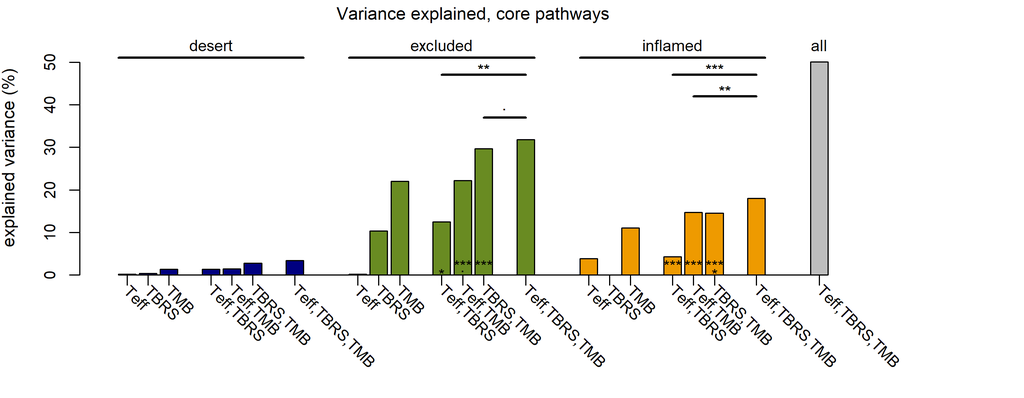

```r
## improvement of Teff, TBRS over single models
if (!is.na(allDat[["inflamed"]][["pvalues"]]["core_tgfbml"])) {
  segments(x0=a[18],
    x1=a[20],
    y0=yLim -18,
    y1=yLim -18,
    col="black",
    xpd=TRUE,
    lwd=2)
}
if (!is.na(allDat[["inflamed"]][["pvalues"]]["core_teffml"])) {
  segments(x0=a[17],
    x1=a[20],
    y0=yLim - 13,
    y1=yLim - 13,
    col="black",
    xpd=TRUE,
    lwd=2)
}
if (!is.na(allDat[["inflamed"]][["pvalues"]]["core_tt"])) {
  segments(x0=a[16],
    x1=a[20],
    y0=yLim -8,
    y1=yLim -8,
    col="black",
    xpd=TRUE,
    lwd=2)
}

if (!is.na(allDat[["excluded"]][["pvalues"]]["core_tgfbml"])) {
  segments(x0=a[29],
    x1=a[31],
    y0=yLim -18,
    y1=yLim -18,
    col="black",
    xpd=TRUE,
    lwd=2)
}
if (!is.na(allDat[["excluded"]][["pvalues"]]["core_teffml"])) {
  segments(x0=a[28],
    x1=a[31],
    y0=yLim - 13,
    y1=yLim - 13,
    col="black",
    xpd=TRUE,
    lwd=2)
}
if (!is.na(allDat[["excluded"]][["pvalues"]]["core_tt"])) {
   segments(x0=a[27],
    x1=a[31],
    y0=yLim -8,
    y1=yLim -8,
    col="black",
    xpd=TRUE,
    lwd=2)
}

text(x = c(median(c(a[18], a[20])),
    median(c(a[17], a[20])),
    median(c(a[16], a[20]))),
  y=c(yLim -16, yLim - 11, yLim -6),
  labels = unlist(allDat[["inflamed"]][["pvalues"]][
    c("core_tgfbml", "core_teffml", "core_tt")]),
  cex=0.9,
  xpd=TRUE)
text(x = c(median(c(a[29], a[31])),
    median(c(a[28], a[31])),
    median(c(a[27], a[31]))),
  y=c(yLim -16, yLim - 11, yLim -6),
  labels = unlist(allDat[["excluded"]][["pvalues"]][
    c("core_tgfbml", "core_teffml", "core_tt")]),
  cex=0.9,
  xpd=TRUE)

text(x = a[16],
  y=c(3, 1),
  labels = unlist(allDat[["inflamed"]][["pvalues"]][c("teffP", "tgfbP")]),
  cex=0.9,
  xpd=TRUE)
text(x = a[27],
  y=c(3, 1),
  labels = unlist(allDat[["excluded"]][["pvalues"]][c("teffP", "tgfbP")]),
  cex=0.9,
  xpd=TRUE)

## improvement of Teff, TMB over single models
text(x = a[6],
  y=c(3, 1),
  labels = unlist(allDat[["desert"]][["pvalues"]][c("teffmlP2", "teffmlP")]),
  cex=0.9,
  xpd=TRUE)
text(x = a[17],
  y=c(3, 1),
  labels = unlist(allDat[["inflamed"]][["pvalues"]][c("teffmlP2", "teffmlP")]),
  cex=0.9,
  xpd=TRUE)
text(x = a[28],
  y=c(3, 1),
  labels = unlist(allDat[["excluded"]][["pvalues"]][c("teffmlP2", "teffmlP")]),
  cex=0.9,
  xpd=TRUE)

## improvement of TBRS, TMB over single models
text(x = a[7],
  y=c(3, 1),
  labels = unlist(allDat[["desert"]][["pvalues"]][c("tgfbmlP_int", "tgfbmlP_int2")]),
  cex=0.9,
  xpd=TRUE)
text(x = a[18],
  y=c(3, 1),
  labels = unlist(allDat[["inflamed"]][["pvalues"]][c("tgfbmlP_int", "tgfbmlP_int2")]),
  cex=0.9,
  xpd=TRUE)
text(x = a[29],
  y=c(3, 1),
  labels = unlist(allDat[["excluded"]][["pvalues"]][c("tgfbmlP_int", "tgfbmlP_int2")]),
  cex=0.9,
  xpd=TRUE)


## improvement of double on final core
if (!is.na(allDat[["inflamed"]][["pvalues"]]["core_tgfbml"])) {
  segments(x0=a[18],
    x1=a[20],
    y0=yLim -18,
    y1=yLim -18,
    col="black",
    xpd=TRUE,
    lwd=2)
}
if (!is.na(allDat[["inflamed"]][["pvalues"]]["core_teffml"])) {
  segments(x0=a[17],
    x1=a[20],
    y0=yLim - 13,
    y1=yLim - 13,
    col="black",
    xpd=TRUE,
    lwd=2)
}
if (!is.na(allDat[["inflamed"]][["pvalues"]]["core_tt"])) {
  segments(x0=a[16],
    x1=a[20],
    y0=yLim -8,
    y1=yLim -8,
    col="black",
    xpd=TRUE,
    lwd=2)
}

if (!is.na(allDat[["excluded"]][["pvalues"]]["core_tgfbml"])) {
  segments(x0=a[29],
    x1=a[31],
    y0=yLim -18,
    y1=yLim -18,
    col="black",
    xpd=TRUE,
    lwd=2)
}
if (!is.na(allDat[["excluded"]][["pvalues"]]["core_teffml"])) {
  segments(x0=a[28],
    x1=a[31],
    y0=yLim - 13,
    y1=yLim - 13,
    col="black",
    xpd=TRUE,
    lwd=2)
}
if (!is.na(allDat[["excluded"]][["pvalues"]]["core_tt"])) {
   segments(x0=a[27],
    x1=a[31],
    y0=yLim -8,
    y1=yLim -8,
    col="black",
    xpd=TRUE,
    lwd=2)
}

text(x = c(median(c(a[18], a[20])),
    median(c(a[17], a[20])),
    median(c(a[16], a[20]))),
  y=c(yLim -16, yLim - 11, yLim -6),
  labels = unlist(allDat[["inflamed"]][["pvalues"]][
    c("core_tgfbml", "core_teffml", "core_tt")]),
  cex=0.9,
  xpd=TRUE)
text(x = c(median(c(a[29], a[31])),
    median(c(a[28], a[31])),
    median(c(a[27], a[31]))),
  y=c(yLim -16, yLim - 11, yLim -6),
  labels = unlist(allDat[["excluded"]][["pvalues"]][
    c("core_tgfbml", "core_teffml", "core_tt")]),
  cex=0.9,
  xpd=TRUE)
```

```r
par(mar=oldMar)
```

# Extended data

## ED Figure 7

```r
#pData(fmone)$binaryResponse <- ifelse(pData(fmone)[, irf] %in% c("CR", "PR"), "CR/PR",
#  ifelse(pData(fmone)[, irf] %in% c("SD", "PD"), "SD/PD", NA_character_))
#pData(fmone)$binaryResponse <- factor(pData(fmone)$binaryResponse,
#  levels=c("CR/PR", "SD/PD"))

goi <- c("APOBEC3B",
  "MKI67",
  "DDR",
  ml)

resp <- "binaryResponse"
tmpDat <- pData(fmone)

ids <- ind_genes[["DDR"]]
tmp <- fmone[featureNames(fmone) %in% ids, ]
mutStatus <- any_mutation(tmp)
mutStatus <- colSums(mutStatus)
tmpDat[, "DDR"] <- mutStatus > 0

tmpDat <- tmpDat[!is.na(tmpDat[, resp]), ]
tmpDat[, resp] <- droplevels(tmpDat[, resp])
tmpDat[, ml] <- as.numeric(tmpDat[, ml])
tmpDat <- tmpDat[!is.na(tmpDat[, ml]) & tmpDat[, ml] > 0, ]
tmpDat[, ml] <- log2(tmpDat[, ml])

mki67 <- setNames(m2["MKI67", ], as.character(pData(cds2)$"ANONPT_ID"))
apo <- setNames(m2["APOBEC3B", ], as.character(pData(cds2)$"ANONPT_ID"))
gene19 <- setNames(pData(cds2)[, "gene19"], as.character(pData(cds2)$"ANONPT_ID"))
tmpDat$MKI67 <- mki67[as.character(tmpDat$"ANONPT_ID")]
tmpDat$APOBEC3B <- apo[as.character(tmpDat$"ANONPT_ID")]
tmpDat$gene19 <- scale(gene19[as.character(tmpDat$"ANONPT_ID")],
  center=TRUE,
  scale=TRUE)
tmpDat <- tmpDat[!is.na(tmpDat$APOBEC3B), ]

varExp2 <- t(sapply(goi, function(sig) {
  fit <- glm(tmpDat[, resp] ~
    tmpDat[, sig],
    family="binomial")
  fit$null.deviance - fit$deviance
}))
varExp2 <- varExp2[1,]

varExp3 <- t(sapply(goi[goi != ml], function(sig) {
  fit2.2 <- glm(tmpDat[, resp] ~
    tmpDat[, ml] + tmpDat[, sig],
    family="binomial")
  fit2.2$null.deviance - fit2.2$deviance
}))
varExp3 <- varExp3[1,]
names(varExp3) <- paste0("TMB,", names(varExp3))

fit4.1 <- glm(tmpDat[, resp] ~
  tmpDat[, ml] * tmpDat[, "gene19"],
  family="binomial")
varExp4.1 <- fit4.1$null.deviance - fit4.1$deviance
names(varExp4.1) <- "TMB,TBRS"
fit4.2 <- glm(tmpDat[, resp] ~
  tmpDat[, ml] * tmpDat[, "gene19"] + tmpDat[, "MKI67"],
  family="binomial")
varExp4.2 <- fit4.2$null.deviance - fit4.2$deviance
names(varExp4.2) <- "TMB,TBRS,MKI67"

varExp <- c(sort(varExp2), sort(varExp3), varExp4.1, varExp4.2)
names(varExp) <- sub(ml, "TMB", names(varExp))
names(varExp) <- sub("Cell cycle regulation", "CCR", names(varExp))

## get p-values
fit_ml_0 <- glm(tmpDat[, resp] ~
  tmpDat[, ml],
  family="binomial")
fit_DDR_0 <- glm(tmpDat[, resp] ~
  tmpDat[, "DDR"],
  family="binomial")
fit_APO_0 <- glm(tmpDat[, resp] ~
  tmpDat[, "APOBEC3B"],
  family="binomial")
fit_KI67_0 <- glm(tmpDat[, resp] ~
  tmpDat[, "MKI67"],
  family="binomial")

fit_ml_ddr <- glm(tmpDat[, resp] ~
  tmpDat[, ml] +
  tmpDat[, "DDR"],
  family="binomial")
fit_ml_apo <- glm(tmpDat[, resp] ~
  tmpDat[, ml] +
  tmpDat[, "APOBEC3B"],
  family="binomial")
fit_ml_ki67 <- glm(tmpDat[, resp] ~
  tmpDat[, ml] +
  tmpDat[, "MKI67"],
  family="binomial")

# likelihood ratio test Ps for display
ddrP <- signif(anova(fit_ml_0, fit_ml_ddr, test="Chisq")$"Pr(>Chi)"[2], 2)
apoP <- signif(anova(fit_ml_0, fit_ml_apo, test="Chisq")$"Pr(>Chi)"[2], 2)
ki67P <- signif(anova(fit_ml_0, fit_ml_ki67, test="Chisq")$"Pr(>Chi)"[2], 2)

ki67P2 <- signif(anova(fit4.1, fit4.2, test="Chisq")$"Pr(>Chi)"[2], 2)

pvals <- list(ddrP=ddrP,
  apoP=apoP,
  ki67P=ki67P,
  ki67P2=ki67P2
  )
print(pvals)
```

```
## $ddrP
## [1] 0.38
##
## $apoP
## [1] 0.26
##
## $ki67P
## [1] 0.029
##
## $ki67P2
## [1] 0.064
```

```r
pvals <- lapply(pvals, function(x) {
  ifelse(x < 0.001, "***",
  ifelse(x < 0.01, "**",
    ifelse(x < 0.05, "*",
      ifelse(x < 0.1, ".", "n.s."))))
})

oldMar <-  par()$mar
par(mar=c(6, 3.9, 2.5, 0))

a <- barplot(varExp,
  main="",
  ylab="explained variance (%)",
  col="grey",
  width=0.068,
  xlim=c(0,1),
  ylim=c(0,40),
  xaxt="n",
  cex.axis=0.9)
axis(1,
  at=a,
  labels=FALSE)
text(x = a,
  y=-3,
  labels = names(varExp),
  srt = -45,
  xpd = TRUE,
  adj=0,
  cex=namesCex)
print("variance explained:")
```

```
## [1] "variance explained:"
```

```r
print(varExp)
```

```
##            DDR       APOBEC3B          MKI67            TMB        TMB,DDR   TMB,APOBEC3B
##       6.322234       7.056243      11.202112      28.845441      29.602905      30.108802
##      TMB,MKI67       TMB,TBRS TMB,TBRS,MKI67
##      33.602873      37.947811      41.389362
```

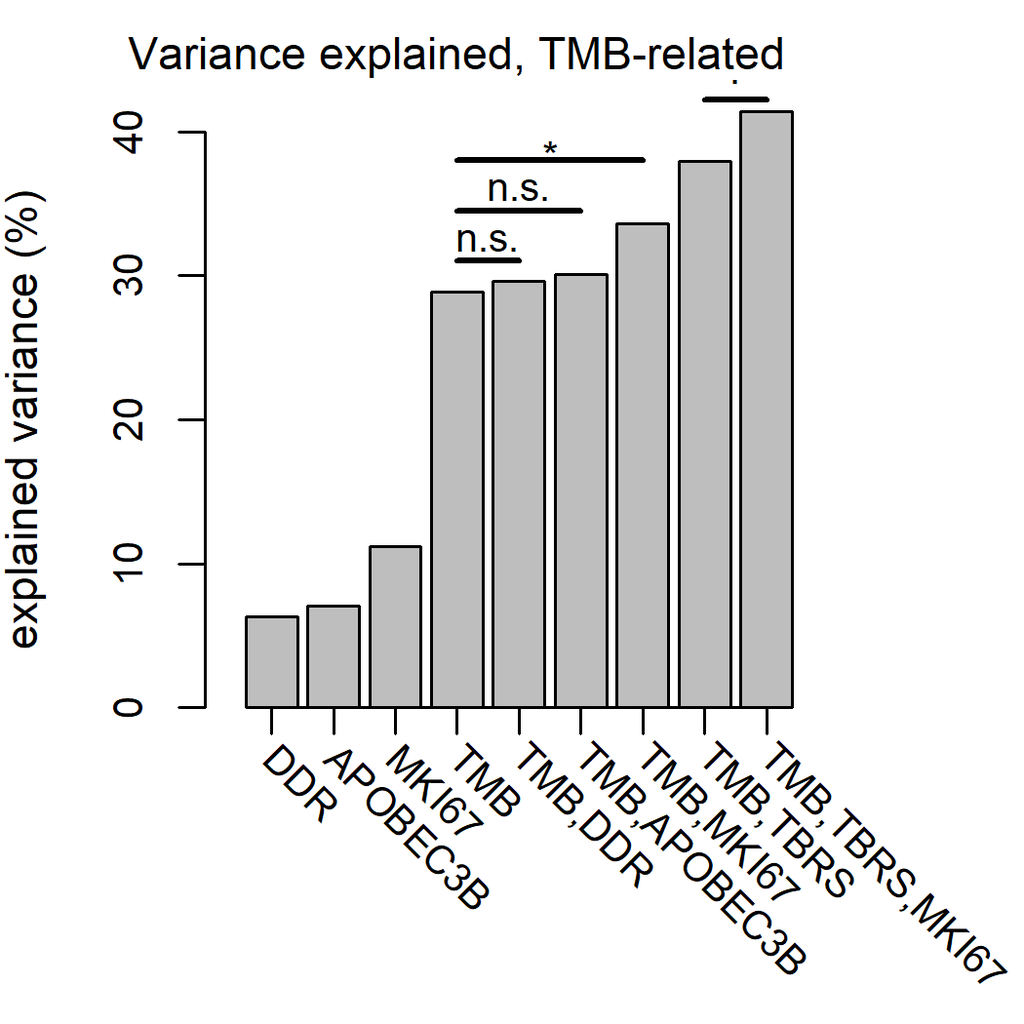

```r
mtext(at = a[4],
  line=1,
  side=3,
  text="Variance explained, TMB-related",
  cex=titleCex,
  font=titleF)

segments(x0=a[4],
  x1=a[5],
  y0=31,
  y1=31,
  col="black",
  xpd=TRUE,
  lwd=2)
text(x = mean(c(a[4], a[5])),
  y=32.5,
  labels = pvals[["ddrP"]],
  #pos=3,
  cex=0.9)

segments(x0=a[4],
  x1=a[6],
  y0=34.5,
  y1=34.5,
  col="black",
  xpd=TRUE,
  lwd=2)
text(x = mean(c(a[4], a[6])),
  y=36,
  labels = pvals[["apoP"]],
  #pos=3,
  cex=0.9)

segments(x0=a[4],
  x1=a[7],
  y0=38,
  y1=38,
  col="black",
  xpd=TRUE,
  lwd=2)
text(x = mean(c(a[4], a[7])),
  y=39,
  labels = pvals[["ki67P"]],
  #pos=3,
  cex=0.9,
  xpd=TRUE)

segments(x0=a[8],
  x1=a[9],
  y0=42.2,
  y1=42.2,
  col="black",
  xpd=TRUE,
  lwd=2)
text(x = mean(c(a[8], a[9])),
  y=43.5,
  labels = pvals[["ki67P2"]],
  #pos=3,
  cex=0.9,
  xpd=TRUE)
```

```r
par(mar=oldMar)
```

## ED Figure 8

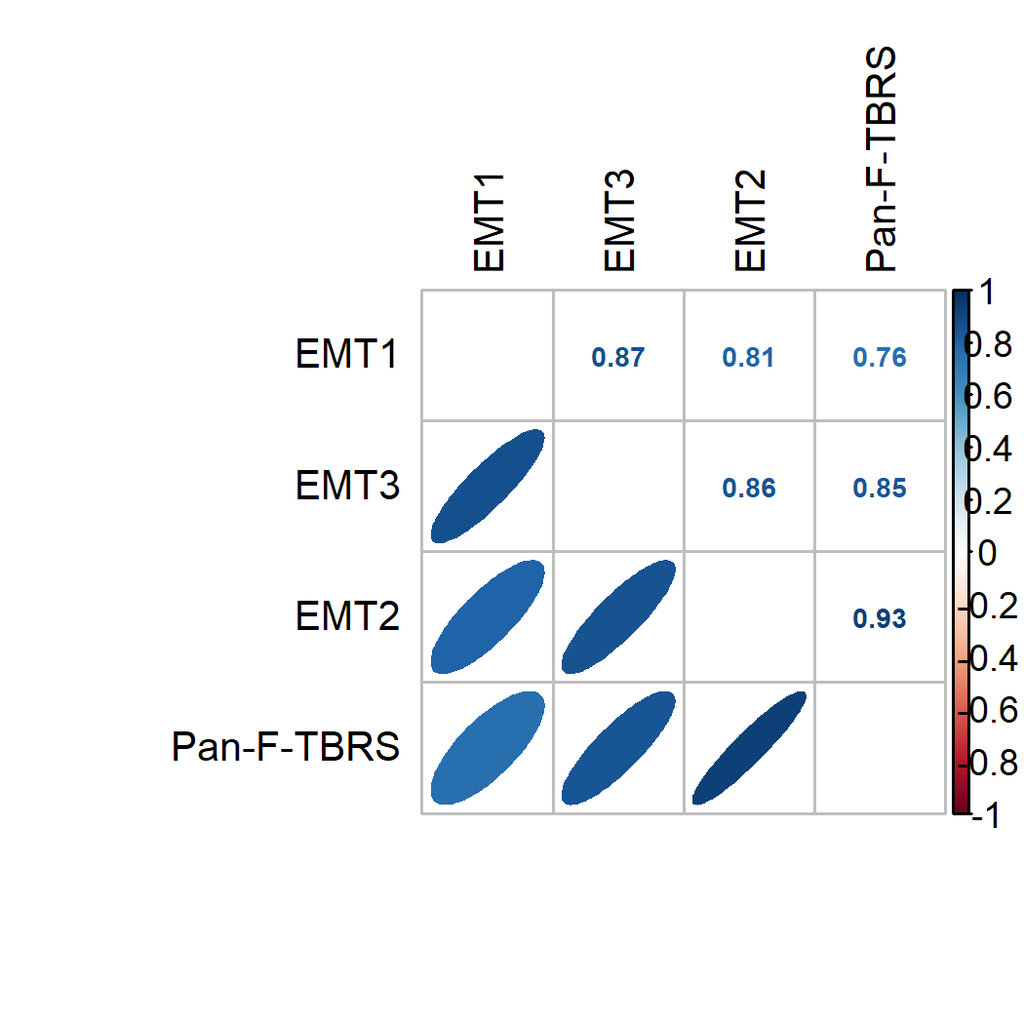

```r
sigs <- c("gene19",
  "EMT1",
  "EMT2",
  "EMT3")
tmp <- pData(cds2)[, sigs]
colnames(tmp) <- sub("gene19", "Pan-F-TBRS", colnames(tmp))
colnames(tmp) <- sub("F-Canonical", "CAF", colnames(tmp))
M <- cor(tmp)
corrplot.mixed(M,
  lower="ellipse",
  upper="number",
  number.cex = 0.6,
  order="AOE",
  tl.cex = 0.9,
  tl.col = "black",
  xpd=TRUE,
  tl.pos="lt",
  diag="n")
```

```
## [1] "Wilcoxon test, unadjusted"
##   desert excluded inflamed
##    0.610    0.016    0.860
## [1] "T test (unadjusted)"
##   desert excluded inflamed
##   0.9800   0.0034   0.8000
## [1] "T test, adjusted"
##   desert excluded inflamed
##   1.0000   0.0102   1.0000
```

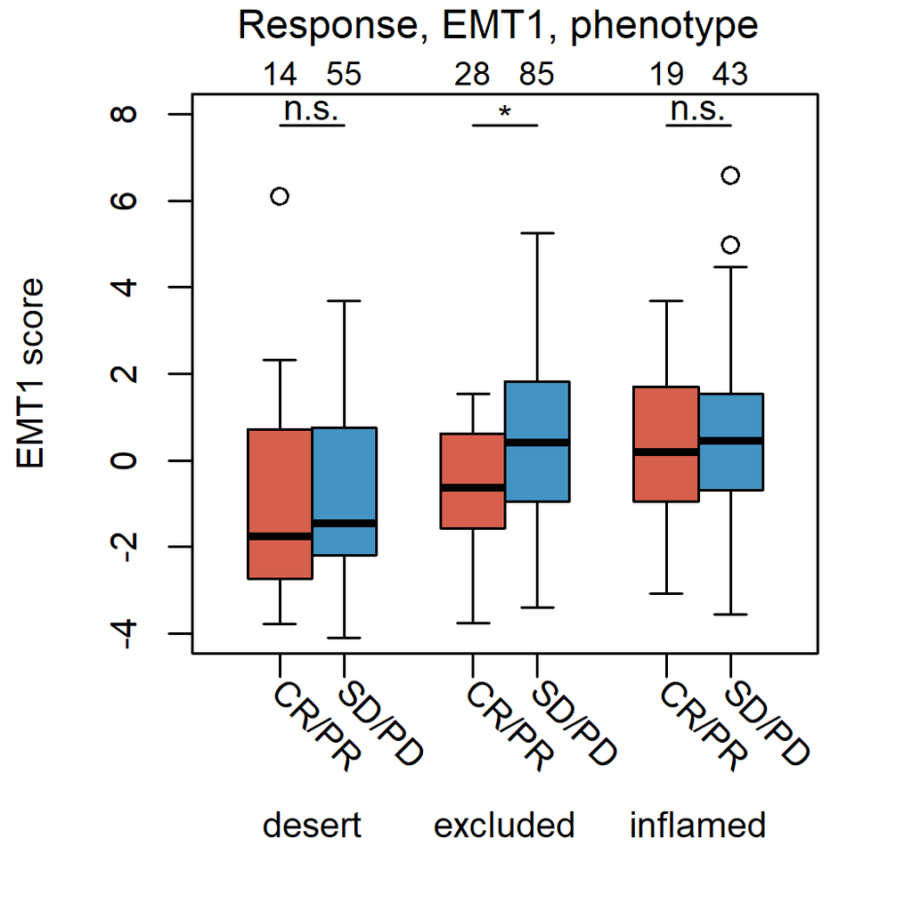

```
## [1] "Wilcoxon test, unadjusted"
##   desert excluded inflamed
##   0.8100   0.0011   0.8800
## [1] "T test (unadjusted)"
##   desert excluded inflamed
##   0.8500   0.0009   0.6300
## [1] "T test, adjusted"
##   desert excluded inflamed
##   1.0000   0.0027   1.0000
```

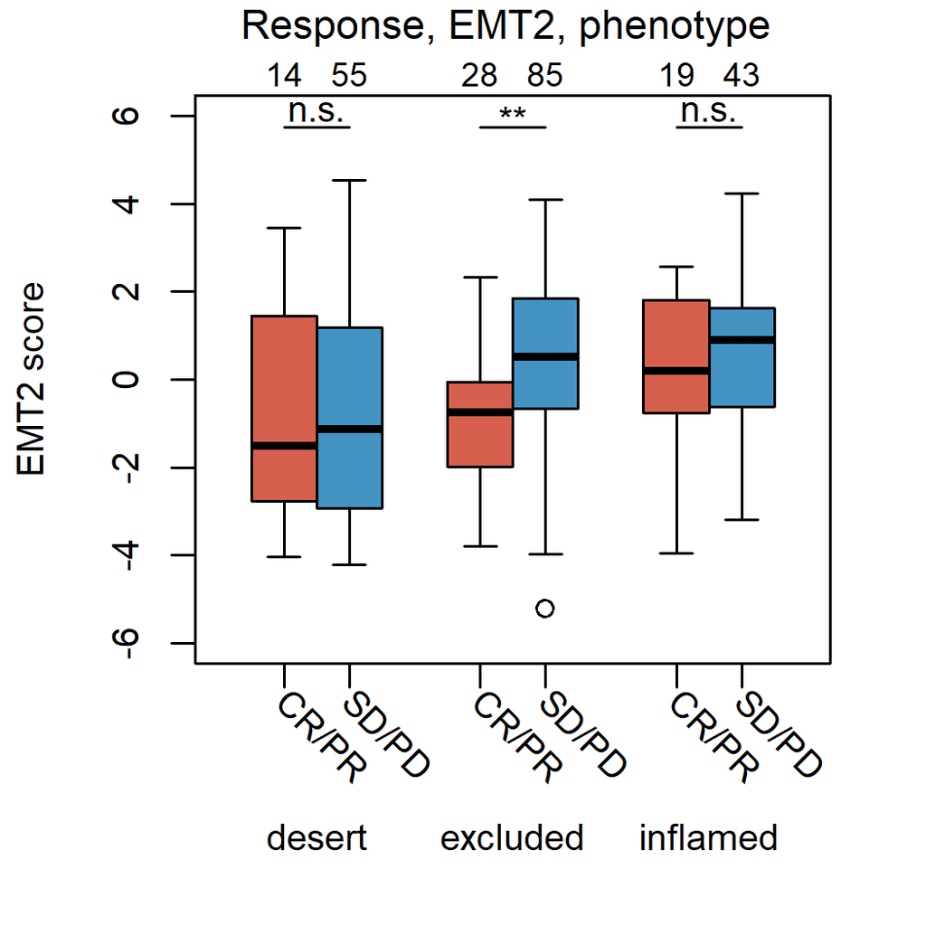

```
## [1] "Wilcoxon test, unadjusted"
##   desert excluded inflamed
##   0.6700   0.0036   0.9600
## [1] "T test (unadjusted)"
##   desert excluded inflamed
##   0.8000   0.0021   0.8800
## [1] "T test, adjusted"
##   desert excluded inflamed
##   1.0000   0.0063   1.0000
```

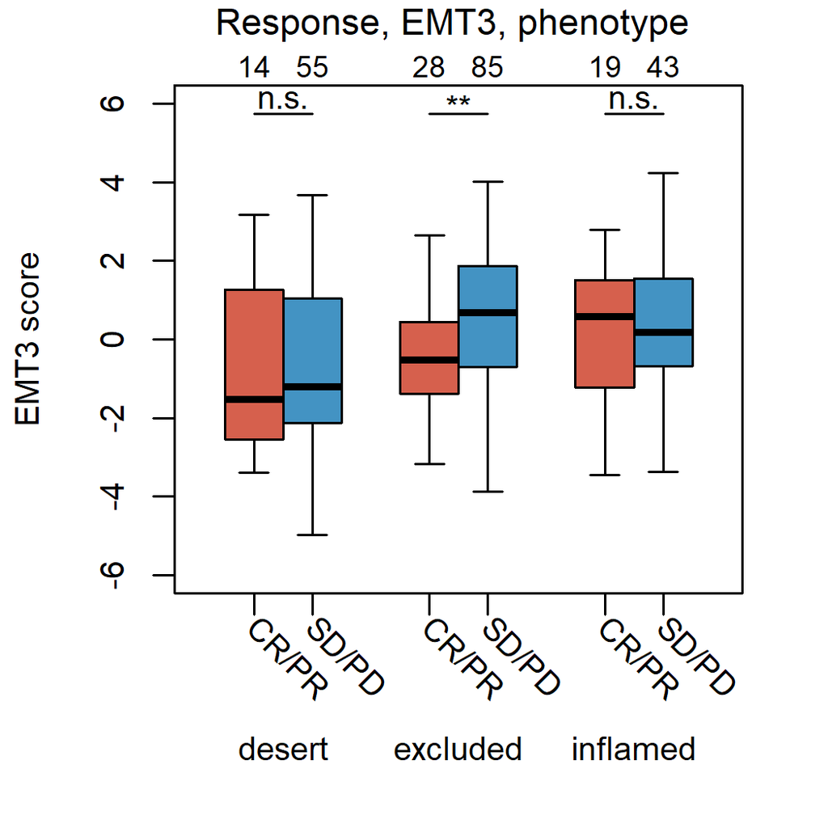

```r
par(mar=c(5.5, 4.1, 2, 2))

sigs <- c("EMT1",
  "EMT2",
  "EMT3")

for (sig in sigs) {

  yLim <- c(-6, 6)
  if (sig == "EMT1") {
    yLim <- c(-4, 8)
  }

  feat <- "Immune phenotype"
  resp <- "binaryResponse"

  dat <- data.frame("Signature"= pData(cds2)[, sig],
    "Immunophenotype"= pData(cds2)[, feat],
    "Response"= pData(cds2)[, resp],
    check.names=FALSE)
  dat <- dat[!is.na(dat$Response) & !is.na(dat$Immunophenotype), ]
  nSamples <- table(dat$Response, dat$Immunophenotype)

  pvals <- c()
  for (cit in levels(pData(cds2)[, feat])) {
    tmp <- dat[dat$Immunophenotype == cit,]
    pvals <- c(pvals,
      signif(getPfromAnova(tmp$Signature, tmp$Response), 2))
  }

    pvals2 <- c()
    for (cit in levels(pData(cds2)[, feat])) {
    tmp <- dat[dat$Immunophenotype == cit,]
    pvals2 <- c(pvals2,
      signif(wilcox.test(tmp$Signature ~ tmp$Response)$p.value, 2))
  }
  print("Wilcoxon test, unadjusted")
  print(setNames(pvals2, levels(pData(cds2)[, feat])))

  pvals2 <- c()
  for (cit in levels(pData(cds2)[, feat])) {
    tmp <- dat[dat$Immunophenotype == cit,]
    pvals2 <- c(pvals2,
      signif(t.test(tmp$Signature ~ tmp$Response)$p.value, 2))
  }
  print("T test (unadjusted)")
  print(setNames(pvals2, levels(pData(cds2)[, feat])))
  print("T test, adjusted")
  pvals2 <- ifelse(pvals2 * 3 > 1, 1, pvals2 * 3)
  print(setNames(pvals2,
    levels(pData(cds2)[, feat])))

  pvals3 <- pLevel(pvals2)

  tmp <- lapply(levels(pData(cds2)[, feat]), function(cit) {
    if (cit == "inflamed") {
      list("CR/PR"=dat$Signature[dat$Response == "CR/PR" & dat$Immunophenotype == cit],
        "SD/PD"=dat$Signature[dat$Response == "SD/PD" & dat$Immunophenotype == cit])
    } else {
      list("CR/PR"=dat$Signature[dat$Response == "CR/PR" & dat$Immunophenotype == cit],
        "SD/PD"=dat$Signature[dat$Response == "SD/PD" & dat$Immunophenotype == cit],
        y=numeric(0))
    }
  })

  par(mar=c(5.5, 4.1, 2, 2))

  at.x <- seq(1, by=0.5, length.out=8)
  a <- boxplot(unlist(tmp, recursive=FALSE),
    ylab=paste(sig, "score"),
    col=color_palettes[["response_palette"]][c(1,2,1,1,2,1,1,2)],
    cex.axis=axisCex,
    cex.lab=labCex,
    cex.names=namesCex,
    whisklty = 1,
    ylim=yLim,
    xaxt="n",
    at=at.x,
    boxwex=0.5)
  axis(1,
    at=c(1,1.5,2.5,3,4,4.5),
    labels=rep("", 6))
  mtext(levels(pData(cds2)[, feat]),
    side=1,
    at=c(1.25, 2.75, 4.25),
    line=3.1,
    cex=namesCex)
  text(x = c(1,1.5,2.5,3,4,4.5),
    y = par("usr")[3] - 0.7 ,
    labels = rep(c("CR/PR", "SD/PD"), 3),
    srt = -45,
    xpd = TRUE,
    adj=0,
    cex=namesCex)
  mtext(nSamples,
    side=3,
    at=c(1,1.5,2.5,3,4,4.5),
    line=0,
    cex=0.8)
  mtext(paste0("Response, ", sig, ", phenotype"),
    side=3,
    at=2.7,
    line=1,
    font=titleF,
    cex=titleCex)

  yrange <- par("usr")[4] - par("usr")[3]
  yunit <- yrange/35
  segments(x0=1,
    x1=1.5,
    y0=par("usr")[4] - yunit * 2,
    y1=par("usr")[4] - yunit * 2,
    col="black",
    xpd=TRUE,
    lwd=1)
  segments(x0=2.5,
    x1=3,
    y0=par("usr")[4] - yunit * 2,
    y1=par("usr")[4] - yunit * 2,
    col="black",
    xpd=TRUE,
    lwd=1)
  segments(x0=4,
    x1=4.5,
    y0=par("usr")[4] - yunit * 2,
    y1=par("usr")[4] - yunit * 2,
    col="black",
    xpd=TRUE,
    lwd=1)
  text(y=ifelse(pvals3 == "n.s.", par("usr")[4] - yunit , par("usr")[4] - yunit),
    x=c(1.25, 2.75, 4.25),
    labels=pvals3,
    cex=axisCex)

}
```

```r
resp <- "binaryResponse"

tmpDat <- pData(cds2)[!is.na(pData(cds2)[, resp]), ]
tmpDat[, resp] <- droplevels(tmpDat[, resp])
goi <- c("CD 8 T effector",
  "gene19",
  "EMT1",
  "EMT2",
  "EMT3")
for (sig in goi) {
  tmpDat[, sig] <- scale(tmpDat[, sig], center=TRUE, scale=TRUE)
}
tmpDat <- tmpDat[!is.na(tmpDat[, ml]) & tmpDat[, ml] > 0, ]
tmpDat[, ml] <- log2(tmpDat[, ml])

fit_emt1_0 <- glm(tmpDat[, resp] ~
  tmpDat[, "EMT1"],
  family="binomial")
summary(fit_emt1_0)$coefficients
```

```
##                   Estimate Std. Error  z value     Pr(>|z|)
## (Intercept)      1.0636227  0.1522800 6.984651 2.855652e-12
## tmpDat[, "EMT1"] 0.1934088  0.1594936 1.212643 2.252664e-01
```

```r
fit_emt2_0 <- glm(tmpDat[, resp] ~
  tmpDat[, "EMT2"],
  family="binomial")
summary(fit_emt2_0)$coefficients
```

```
##                   Estimate Std. Error  z value     Pr(>|z|)
## (Intercept)      1.0787740  0.1537142 7.018049 2.249877e-12
## tmpDat[, "EMT2"] 0.2722915  0.1564879 1.740017 8.185610e-02
```

```r
fit_emt3_0 <- glm(tmpDat[, resp] ~
  tmpDat[, "EMT3"],
  family="binomial")
summary(fit_emt3_0)$coefficients
```

```
##                   Estimate Std. Error  z value     Pr(>|z|)
## (Intercept)      1.0803340  0.1538697 7.021095 2.201358e-12
## tmpDat[, "EMT3"] 0.2799817  0.1573326 1.779553 7.514918e-02
```

```r
fit_tbrs_0 <- glm(tmpDat[, resp] ~
  tmpDat[, "gene19"],
  family="binomial")
summary(fit_tbrs_0)$coefficients
```

```
##                     Estimate Std. Error  z value     Pr(>|z|)
## (Intercept)        1.0937374  0.1554196 7.037320 1.959719e-12
## tmpDat[, "gene19"] 0.3510211  0.1605621 2.186201 2.880090e-02
```

```r
fit_tbrs_emt1 <- glm(tmpDat[, resp] ~
  tmpDat[, "gene19"] + tmpDat[, "EMT1"],
  family="binomial")
anova(fit_tbrs_0, fit_tbrs_emt1, test="Chisq")
```

```
## Analysis of Deviance Table
##
## Model 1: tmpDat[, resp] ~ tmpDat[, "gene19"]
## Model 2: tmpDat[, resp] ~ tmpDat[, "gene19"] + tmpDat[, "EMT1"]
##   Resid. Df Resid. Dev Df Deviance Pr(>Chi)
## 1       231     262.96
## 2       230     262.39  1  0.56532   0.4521
```

```r
fit_tbrs_emt2 <- glm(tmpDat[, resp] ~
  tmpDat[, "gene19"] + tmpDat[, "EMT2"],
  family="binomial")
anova(fit_tbrs_0, fit_tbrs_emt2, test="Chisq")
```

```
## Analysis of Deviance Table
##
## Model 1: tmpDat[, resp] ~ tmpDat[, "gene19"]
## Model 2: tmpDat[, resp] ~ tmpDat[, "gene19"] + tmpDat[, "EMT2"]
##   Resid. Df Resid. Dev Df Deviance Pr(>Chi)
## 1       231     262.96
## 2       230     262.15  1  0.81314   0.3672
```

```r
fit_tbrs_emt3 <- glm(tmpDat[, resp] ~
  tmpDat[, "gene19"] + tmpDat[, "EMT3"],
  family="binomial")
anova(fit_tbrs_0, fit_tbrs_emt3, test="Chisq")
```

```
## Analysis of Deviance Table
##
## Model 1: tmpDat[, resp] ~ tmpDat[, "gene19"]
## Model 2: tmpDat[, resp] ~ tmpDat[, "gene19"] + tmpDat[, "EMT3"]
##   Resid. Df Resid. Dev Df Deviance Pr(>Chi)
## 1       231     262.96
## 2       230     262.90  1 0.058362   0.8091
```

```r
## plot
sigs <- c("EMT1", "EMT2", "EMT3", "gene19")

varExp2 <- t(sapply(sigs, function(sig) {
  fit <- glm(tmpDat[, resp] ~
    tmpDat[, sig],
    family="binomial")
  fit$null.deviance - fit$deviance
}))
varExp2 <- varExp2[1,]

varExp3 <- t(sapply(sigs[sigs != "gene19"], function(sig) {
  fit2.2 <- glm(tmpDat[, resp] ~
    tmpDat[, "gene19"] + tmpDat[, sig],
    family="binomial")
  fit2.2$null.deviance - fit2.2$deviance
}))
varExp3 <- varExp3[1,]
names(varExp3) <- paste("TBRS +", names(varExp3))

varExp <- c(varExp2, varExp3)
names(varExp) <- sub("gene19", "Pan-F-TBRS", names(varExp))

print("variance explained:")
```

```
## [1] "variance explained:"
```

```r
print(varExp)
```

```
##        EMT1        EMT2        EMT3  Pan-F-TBRS TBRS + EMT1 TBRS + EMT2 TBRS + EMT3
##    1.498405    3.076785    3.223490    4.958490    5.523808    5.771629    5.016852
```

```r
emt1P <- signif(anova(fit_tbrs_0, fit_tbrs_emt1, test="Chisq")$"Pr(>Chi)"[2], 2)
emt2P <- signif(anova(fit_tbrs_0, fit_tbrs_emt2, test="Chisq")$"Pr(>Chi)"[2], 2)
emt3P <- signif(anova(fit_tbrs_0, fit_tbrs_emt3, test="Chisq")$"Pr(>Chi)"[2], 2)

pvals <- list(emt1P=emt1P,
  emt2P=emt2P,
  emt3P=emt3P)
print(pvals)
```

```
## $emt1P
## [1] 0.45
##
## $emt2P
## [1] 0.37
##
## $emt3P
## [1] 0.81
```

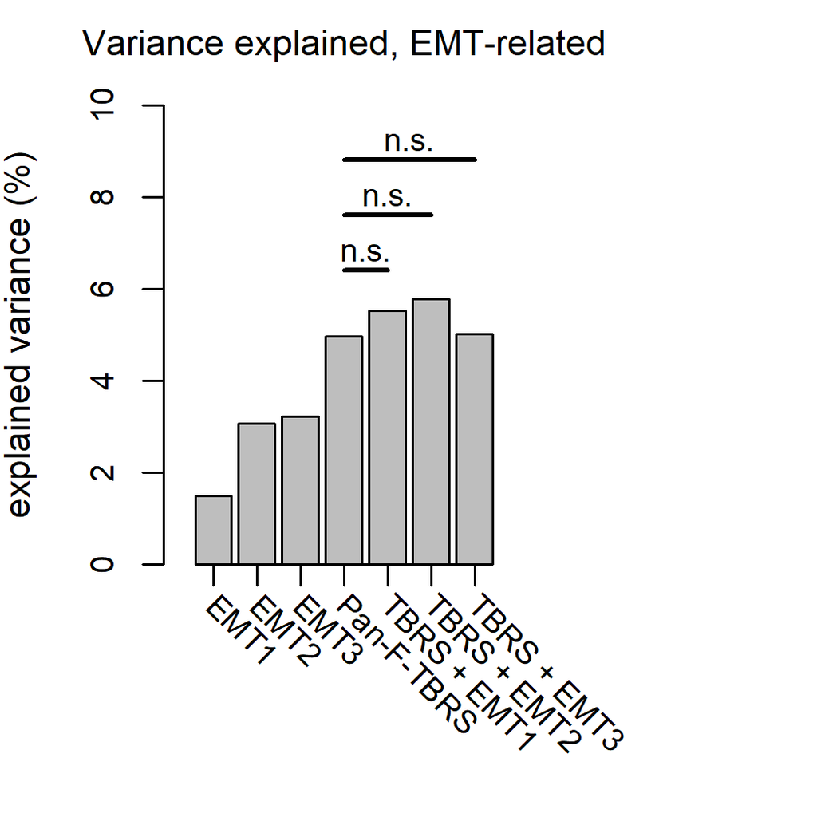

```r
pvals <- lapply(pvals, function(x) {
  ifelse(x < 0.001, "***",
  ifelse(x < 0.01, "**",
    ifelse(x < 0.05, "*",
      ifelse(x < 0.1, ".", "n.s."))))
})

oldMar <-  par()$mar
par(mar=c(6, 3.9, 2.5, 0))
a <- barplot(varExp,
  main="",
  ylab="explained variance (%)",
  col="grey",
  width=0.06,
  xlim=c(0,1),
  ylim=c(0,10),
  #args.legend=list(bg=alpha("white", 0.7),
  #  box.col=alpha("white", 0.7),
  #  cex=0.9),
  xaxt="n",
  cex.axis=0.9)
axis(1,
  at=a,
  labels=FALSE)
text(x = a,
  y=-0.75,
  labels = names(varExp),
  srt = -45,
  #pos = 1,
  xpd = TRUE,
  adj=0,
  cex=namesCex)
mtext(at = a[4],
  line=1,
  side=3,
  text="Variance explained, EMT-related",
  cex=titleCex,
  font=titleF)

segments(x0=a[4],
  x1=a[5],
  y0=6.4,
  y1=6.4,
  col="black",
  xpd=TRUE,
  lwd=2)
text(x = mean(c(a[4], a[5])),
  y=6.8,
  labels = pvals[["emt1P"]],
  cex=0.9)

segments(x0=a[4],
  x1=a[6],
  y0=7.6,
  y1=7.6,
  col="black",
  xpd=TRUE,
  lwd=2)
text(x = mean(c(a[4], a[6])),
  y=8,
  labels = pvals[["emt2P"]],
  cex=0.9)

segments(x0=a[4],
  x1=a[7],
  y0=8.8,
  y1=8.8,
  col="black",
  xpd=TRUE,
  lwd=2)
text(x = mean(c(a[4], a[7])),
  y=9.2,
  labels = pvals[["emt3P"]],
  cex=0.9,
  xpd=TRUE)
```

#### Session Info

[1] “2021-01-28 01:38:47” R version 4.0.3 (2020-10-10) Platform: x86_64-w64-mingw32/x64 (64-bit) Running under: Windows 10 x64 (build 18363)

Matrix products: default

locale: [1] LC_COLLATE=Chinese (Simplified)_China.936 LC_CTYPE=Chinese (Simplified)_China.936  
[3] LC_MONETARY=Chinese (Simplified)_China.936 LC_NUMERIC=C  
[5] LC_TIME=Chinese (Simplified)_China.936

attached base packages: [1] grid stats4 parallel stats graphics grDevices utils datasets [9] methods base

other attached packages: [1] survival_3.2-7 corrplot_0.84  
[3] ComplexHeatmap_2.6.2 edgeR_3.32.1  
[5] limma_3.46.0 DESeq2_1.30.0  
[7] SummarizedExperiment_1.20.0 MatrixGenerics_1.2.0  
[9] matrixStats_0.57.0 GenomicRanges_1.42.0  
[11] GenomeInfoDb_1.26.2 IRanges_2.24.1  
[13] S4Vectors_0.28.1 DT_0.17  
[15] lsmeans_2.30-0 emmeans_1.5.3  
[17] spatstat_1.64-1 rpart_4.1-15  
[19] nlme_3.1-151 spatstat.data_1.7-0  
[21] ggplot2_3.3.3 reshape2_1.4.4  
[23] plyr_1.8.6 rmarkdown_2.6  
[25] knitr_1.30 IMvigor210CoreBiologies_2.0.0 [27] Biobase_2.50.0 BiocGenerics_0.36.0  
[29] biomaRt_2.46.1 devtools_2.3.2  
[31] usethis_2.0.0

loaded via a namespace (and not attached): [1] circlize_0.4.12 BiocFileCache_1.14.0 splines_4.0.3  
[4] BiocParallel_1.24.1 crosstalk_1.1.1 TH.data_1.0-10  
[7] digest_0.6.27 htmltools_0.5.1.1 fansi_0.4.2  
[10] magrittr_2.0.1 memoise_2.0.0 cluster_2.1.0  
[13] tensor_1.5 remotes_2.2.0 annotate_1.68.0  
[16] sandwich_3.0-0 askpass_1.1 prettyunits_1.1.1  
[19] colorspace_2.0-0 blob_1.2.1 rappdirs_0.3.1  
[22] xfun_0.20 dplyr_1.0.3 callr_3.5.1  
[25] crayon_1.3.4 RCurl_1.98-1.2 jsonlite_1.7.2  
[28] genefilter_1.72.1 zoo_1.8-8 glue_1.4.2  
[31] polyclip_1.10-0 gtable_0.3.0 zlibbioc_1.36.0  
[34] XVector_0.30.0 GetoptLong_1.0.5 DelayedArray_0.16.1  
[37] pkgbuild_1.2.0 shape_1.4.5 abind_1.4-5  
[40] scales_1.1.1 DESeq_1.39.0 mvtnorm_1.1-1  
[43] DBI_1.1.1 Rcpp_1.0.6 xtable_1.8-4  
[46] progress_1.2.2 clue_0.3-58 bit_4.0.4  
[49] htmlwidgets_1.5.3 httr_1.4.2 RColorBrewer_1.1-2  
[52] ellipsis_0.3.1 pkgconfig_2.0.3 XML_3.99-0.5  
[55] farver_2.0.3 dbplyr_2.0.0 deldir_0.2-9  
[58] locfit_1.5-9.4 tidyselect_1.1.0 labeling_0.4.2  
[61] rlang_0.4.10 AnnotationDbi_1.52.0 munsell_0.5.0  
[64] tools_4.0.3 cachem_1.0.1 cli_2.2.0  
[67] generics_0.1.0 RSQLite_2.2.3 evaluate_0.14  
[70] stringr_1.4.0 fastmap_1.1.0 yaml_2.2.1  
[73] goftest_1.2-2 processx_3.4.5 bit64_4.0.5  
[76] fs_1.5.0 purrr_0.3.4 xml2_1.3.2  
[79] compiler_4.0.3 rstudioapi_0.13 curl_4.3  
[82] png_0.1-7 testthat_3.0.1 spatstat.utils_2.0-0  
[85] tibble_3.0.5 geneplotter_1.68.0 stringi_1.5.3  
[88] highr_0.8 ps_1.5.0 desc_1.2.0  
[91] lattice_0.20-41 Matrix_1.3-2 vctrs_0.3.6  
[94] pillar_1.4.7 lifecycle_0.2.0 BiocManager_1.30.10  
[97] GlobalOptions_0.1.2 estimability_1.3 bitops_1.0-6  
[100] R6_2.5.0 sessioninfo_1.1.1 codetools_0.2-18  
[103] MASS_7.3-53 assertthat_0.2.1 pkgload_1.1.0  
[106] rjson_0.2.20 openssl_1.4.3 rprojroot_2.0.2  
[109] withr_2.4.1 multcomp_1.4-15 GenomeInfoDbData_1.2.4 [112] mgcv_1.8-33 hms_1.0.0 coda_0.19-4  
[115] Cairo_1.5-12.2